# Prob 4, CP 1

Daniyel

23 de julho de 2017

```r
#bibliotecas
library(tidyverse, quietly = TRUE)
library(dplyr, quietly = TRUE)
library(ggplot2)
library(tidyverse, quietly = TRUE)
library(resample, quietly = TRUE)
library(GGally, quietly = TRUE)
library(gridExtra, quietly = TRUE)
theme_set(theme_bw())
```

## Dados

Os dados analisados são referentes aos commits realizados no Github. Como iremos analisar as linguagens de programação com base na extensão dos arquivos commitados, podemos observar a quantidade de commits para cada linguagem.

```r
#dados
github_data <- read.csv("https://raw.githubusercontent.com/nazareno/fpcc2/master/datasets/github-users-committing-filetypes.csv")
#glimpse(github_data)

github_data %>%
  group_by(file_extension) %>%
  count(.)
```

```
## # A tibble: 42 x 2
## # Groups:   file_extension [42]
##    file_extension     n
##            <fctr> <int>
##  1              c   493
##  2             cc    15
##  3         config     5
##  4            cpp   496
##  5             cs   493
##  6         csproj   366
##  7            css   496
##  8            eot    50
##  9            gif    18
## 10             go   442
## # ... with 32 more rows
```

Nossas perguntas requerem que tenhamos informações sobre as datas e os dias da semana dos commits feitos. Para isso iremos adicionar as colunas que nos trazem tais informações. Também iremos escolher as linguagens `Java` e `Python` para continuar a análise.

```r
#informações de data e dia da semana
github_data <- github_data %>%
  mutate(date = paste(the_year,the_month,month_day,sep='-') %>% as.Date(.))

github_data$weekday <- weekdays(as.Date(github_data$date))

github_data <- github_data %>%
  mutate(is_weekend = ifelse(weekday %in% c("sábado","domingo"),TRUE,FALSE))

#filtrando as extensoes que queremos
dados_filtrados <- github_data %>%
  filter(file_extension %in% c("java","py"))
```

Dos dados escolhidos, podemos visualizar uma linha do tempo para nos trazer informações acerca das linguagens escolhidas e os commits de cada uma. Podemos facilmente observar que no início de cada ano, a quanitade de commits diminui consideravelmente.

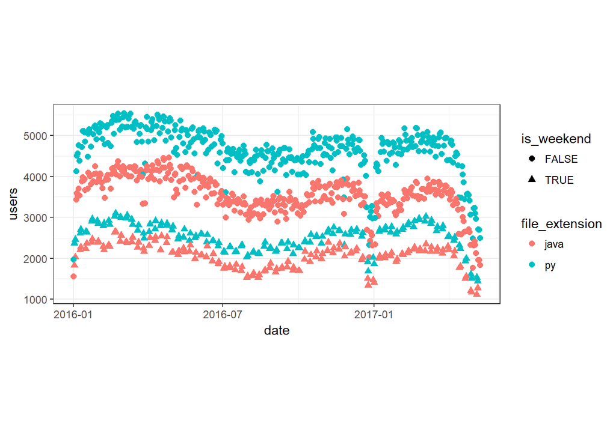

```r
dados_filtrados %>%
  filter(date > 2017-07-01) %>%
  ggplot(aes(x = date, y = users, color=file_extension, shape=is_weekend)) +
  geom_point(size = 2) +
  coord_fixed(ratio = 0.05)
```

## Questão 1

- *Para cada uma delas, há uma diferença significativa na sua popularidade durante a semana e durante o fim de semana? Essa diferença é grande?*

Inicialmente iremos filtrar e tratar os dados, para facilitar o trabalho dos dados de fim de semana e semana, de cada uma das linguagens. Os outliers serão tratados também, para uma melhor visualização da distribuição.

```r
#dados sobre a linguagem java
dados_java <- dados_filtrados %>%
  select(file_extension, users, is_weekend) %>%
  filter(file_extension == "java")
java_fds <- dados_java %>%
  filter(is_weekend == TRUE,users>1250,users<2600)
java_semana <- dados_java %>%
  filter(is_weekend == FALSE,users>2750)

#dados sobre a linguagem python
dados_python <- dados_filtrados %>%
  select(file_extension, users, is_weekend) %>%
  filter(file_extension == "py")
python_fds <- dados_python %>%
  filter(is_weekend == TRUE,users>1750)
python_semana <- dados_python %>%
  filter(is_weekend == FALSE,users>3750)
```

No segundo momento, iremos observar a distribuição amostral da popularidade de cada uma das linguagens nos fins de semana e nos dias de semana.

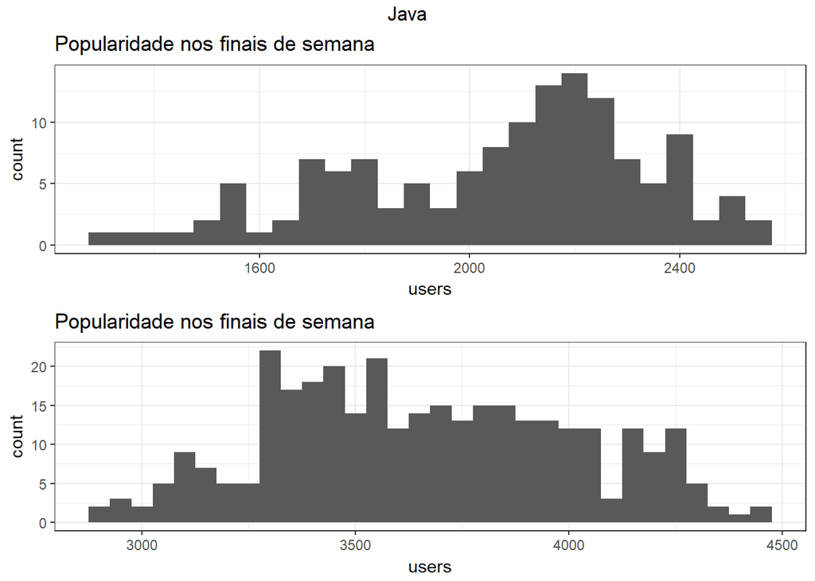

```r
#Analisando a distribuicao amostral para java, comparando a popularidade no fds e nos dias de semana
j1 <- java_fds %>%
  ggplot(aes(users)) +
  geom_histogram(binwidth = 50) +
  labs(title = "Popularidade nos finais de semana")
j2 <- java_semana %>%
  ggplot(aes(users)) +
  geom_histogram(binwidth = 50) +
  labs(title = "Popularidade nos finais de semana")
grid.arrange(j1,j2, top = "Java")
```

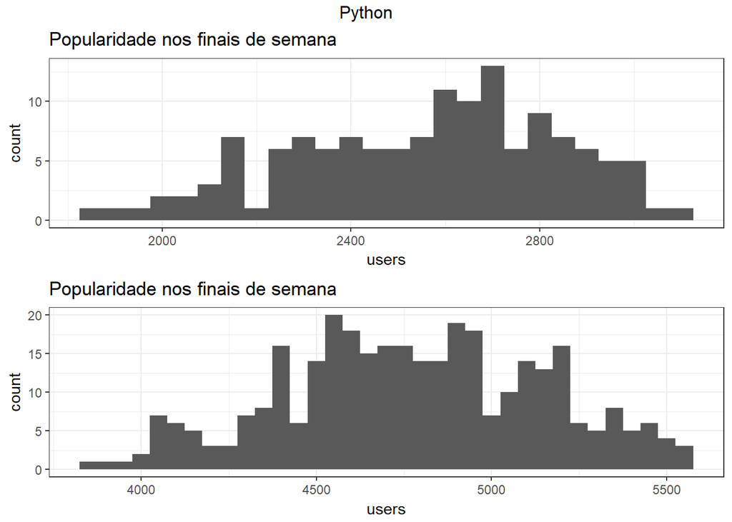

```r
#Analisando a distribuicao amostral para python, comparando a popularidade no fds e nos dias de semana
p1 <- python_fds %>%
  ggplot(aes(users)) +
  geom_histogram(binwidth = 50) +
  labs(title = "Popularidade nos finais de semana")
p2 <- python_semana %>%
  ggplot(aes(users)) +
  geom_histogram(binwidth = 50) +
  labs(title = "Popularidade nos finais de semana")
grid.arrange(p1,p2, top = "Python")
```

Para responder a essa pergunta, iremos definir a média como a estátistica a ser análisada. Tendo a média como nossa estatística para a comparação, iremos realizar a comparação entre popularidade para cada uma das linguagens escolhidas utilizando o bootstrap.

```r
#amostra da linguagem java
amostra_java_fds <- sample_n(java_fds, 100)
colnames(amostra_java_fds) <- c("file_extension","users_java_fds","is_weekend")
amostra_java_semana <- sample_n(java_semana, 100)
colnames(amostra_java_semana) <- c("file_extension","users_java_sem","is_weekend")

#bootstrap
b <- bootstrap(amostra_java_fds, mean(users_java_fds))
media_j1 <- CI.bca(b, probs = c(.025, .975))
media_j1
```

```
##                          2.5%    97.5%
## mean(users_java_fds) 2017.994 2131.379
```

```r
b <- bootstrap(amostra_java_semana, mean(users_java_sem))
media_j2 <- CI.bca(b, probs = c(.025, .975))
media_j2
```

```
##                          2.5%    97.5%
## mean(users_java_sem) 3616.457 3757.863
```

```r
#amostra da linguagem python
amostra_pyhton_fds <- sample_n(python_fds, 100)
colnames(amostra_pyhton_fds) <- c("file_extension","users_python_fds","is_weekend")
amostra_pyhton_semana <- sample_n(python_semana, 100)
colnames(amostra_pyhton_semana) <- c("file_extension","users_python_sem","is_weekend")

#bootstrap
b <- bootstrap(amostra_pyhton_fds, mean(users_python_fds))
media_p1 <- CI.bca(b, probs = c(.025, .975))
media_p1
```

```
##                            2.5%    97.5%
## mean(users_python_fds) 2517.091 2625.361
```

```r
b <- bootstrap(amostra_pyhton_semana, mean(users_python_sem))
media_p2 <- CI.bca(b, probs = c(.025, .975))
media_p2
```

```
##                            2.5%    97.5%
## mean(users_python_sem) 4696.266 4846.704
```

Podemos apresentar essas informações graficamente para facilitar a compreensão.

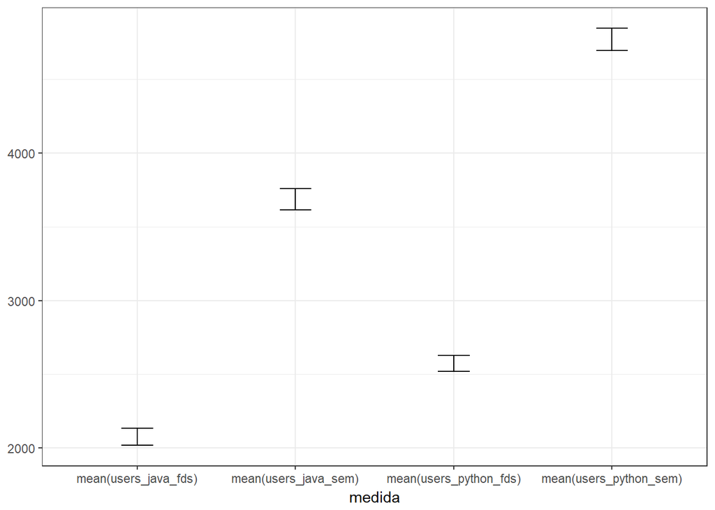

```r
df <- data.frame(rbind(media_j1,
                      media_j2,
                      media_p1,
                      media_p2))
df$medida = row.names(df)
df %>%
  ggplot(aes(x = medida, ymin = X2.5., ymax = X97.5.)) +
  geom_errorbar(width = .2)
```

Observando o gráfico, podemos ver que, para cada linguagem, a diferença da média de usuários realizando commits é significativa. Tendo em vista que os valores estão muito discrepantes uns dos outros, podemos dizer que para essas linguagens muitos mais commits são feitos durante a semana do que em relação ao fim de semana, utilzando a média desses commits para realizar o comparativo.

## Questão 2

- *Existe uma diferença significativa entre as duas linguagens na sua variação de popularidade nos finais de semana?*  
  Para analisar a diferença na variação da popularidade entre as duas linguagens no fim de semana, vamos usar o desvio padrão como nossa estatística. As amostras serão as mesmas utilizadas para responder a pergunta anterior. Então só aplicaremos o bootstrap para a amostra dos commits de cada uma das linguagens feitos durante o fim de semana.

```r
#bootstrap para java utilizando as amostras feitas anteriormente
b <- bootstrap(amostra_java_fds, sd(users_java_fds))
sd_j1 <- CI.bca(b, probs = c(.025, .975))
sd_j1
```

```
##                        2.5%    97.5%
## sd(users_java_fds) 243.0372 319.7283
```

```r
#bootstrap para python utilizando as amostras feitas anteriormente
b <- bootstrap(amostra_pyhton_fds, sd(users_python_fds))
sd_p1 <- CI.bca(b, probs = c(.025, .975))
sd_p1
```

```
##                          2.5%    97.5%
## sd(users_python_fds) 245.3653 311.2148
```

Representando graficamente, temos:

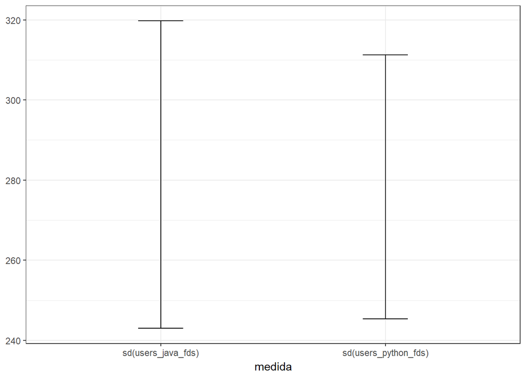

```r
# glimpse(sd_j1)
# sd_j1
df <- data.frame(rbind(sd_j1,
                      sd_p1))
df$medida = row.names(df)
df %>%
  ggplot(aes(x = medida, ymin = X2.5., ymax = X97.5.)) +
  geom_errorbar(width = .2)
```

Para este caso, os intervalos se interceptam e não podemos observar uma diferença significativa. Ou seja, com base nos intervalos de confiança obtidos, não podemos dizer qual das duas linguagens apresenta maior variação nos commits durante o fim de semana.